# Project 2: Data Imputation

Titova Ekaterina, Bobrikov Dmitri, Alekhina Anastasia

2023-11-12

## Group contribution

Dmitri: Data description, Amelia method, Diagnostics of imputation, Estimation of performed imputation

Ekaterina: Descriptive statistics, Mice method

Anastasia: Recoding, Missranger method, exploration and visualization of NA

## Description of the data

We have chosen World Value Survey dataset from 6th round in Russia (2010-2011 years of conducting). It has a lot of information about different values of people, their opinions and many other essential things for social scientists. We would like to select distinct variables to impute data there, so the next possible modelling with usage of these variables would be better. Thus, it would help to understand people in Russia of those years better.

We would like to ease modelling for *level of satisfaction of life* prediction, imputing $Sex$, $Age$, $Education$ $level$, $Income$ $level$, $Religiosity$ $level$, $Level$ $of$ $work$ $importance$, $Level$ $of$ $politics$ $importance$, $Level$ $of$ $financial$ $satisfaction$ $of$ $household$, $Level$ $of$ $trust$ $in$ $people$.

## Exploring data

In this table you can see the name of the variable itself, the class to which it belongs, and the interpretation of the variable itself.

```r
#Class transformation
data1$age <- as.numeric(as.character(data1$age))
data1$satisf_life <- dplyr::case_when(data1$satisf_life == "Completely dissatisfied" ~ 1,
                             data1$satisf_life == "2" ~ 2,
                             data1$satisf_life == "3" ~ 3,
                             data1$satisf_life == "4" ~ 4,
                             data1$satisf_life == "5" ~ 5,
                             data1$satisf_life == "6" ~ 6,
                             data1$satisf_life == "7" ~ 7,
                             data1$satisf_life == "8" ~ 8,
                             data1$satisf_life == "9" ~ 9,
                             data1$satisf_life == "Completely satisfied" ~ 10)

data1$satisf_fin <- dplyr::case_when(data1$satisf_fin == "Completely dissatisfied" ~ 1,
                             data1$satisf_fin == "2" ~ 2,
                             data1$satisf_fin == "3" ~ 3,
                             data1$satisf_fin == "4" ~ 4,
                             data1$satisf_fin == "5" ~ 5,
                             data1$satisf_fin == "6" ~ 6,
                             data1$satisf_fin == "7" ~ 7,
                             data1$satisf_fin == "8" ~ 8,
                             data1$satisf_fin == "9" ~ 9,
                             data1$satisf_fin == "Completely satisfied" ~ 10)

data1$income <- dplyr::case_when(data1$income == "Lower step" ~ 1,
                          data1$income == "second step" ~ 2,
                          data1$income == "Third step" ~ 3,
                          data1$income == "Fourth step" ~ 4,
                          data1$income == "Fifth step" ~ 5,
                          data1$income == "Sixth step" ~ 6,
                          data1$income == "Seventh step" ~ 7,
                          data1$income == "Eigth step" ~ 8,
                          data1$income == "Nineth step" ~ 9,
                          data1$income == "Tenth step" ~ 10)


#Table creation
Table <- matrix(c("sex", 'age', "edu","income",'satisf_life',"religion", 'work', "politics","satisf_fin","trust", class(data1$sex), class(data1$age), class(data1$edu), class(data1$income),  class(data1$satisf_life), class(data1$religion), class(data1$work), class(data1$politics), class(data1$satisf_fin), class(data1$trust),
 "Gender of respondent", "Age of respondent", "Level of education", "Income decile", "Level of life satisfaction","Level of religiosity", "Level of importance of work in life", "Level of importance of politics in life", "Satisfaction with financial situation of household", "Level of trust in people"), ncol = 3)
colnames(Table) <- c("Variables", "Class", "Description")
Table <- as.data.frame(Table)
knitr::kable(Table)%>%   kable_styling(bootstrap_options = c("striped", "hover", "condensed"))
```

| Variables | Class | Description |
| --- | --- | --- |
| sex | factor | Gender of respondent |
| age | numeric | Age of respondent |
| edu | factor | Level of education |
| income | numeric | Income decile |
| satisf_life | numeric | Level of life satisfaction |
| religion | factor | Level of religiosity |
| work | factor | Level of importance of work in life |
| politics | factor | Level of importance of politics in life |
| satisf_fin | numeric | Satisfaction with financial situation of household |
| trust | factor | Level of trust in people |

Lets have a look at the distribution of categorical variables:

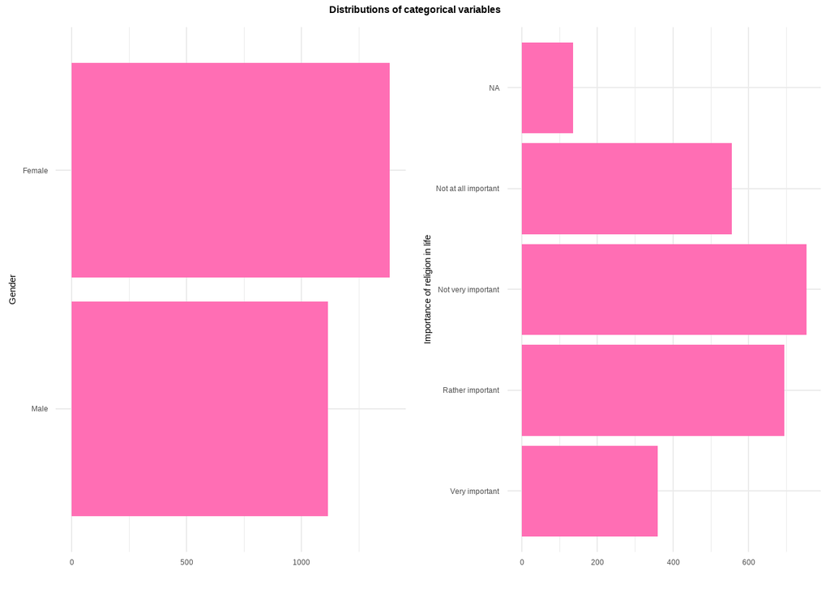

```r
p1 <- ggplot(data1, aes(x = sex)) +
  geom_bar(fill = "#FF6EB4") +labs(x="Gender",y="") +
  coord_flip() +
  theme_minimal()

p2 <- ggplot(data1, aes(x = edu)) +
  geom_bar(fill = "#FF6EB4") +labs(x="Level of education",y="") +
  coord_flip() +
  theme_minimal()

p4 <- ggplot(data1, aes(x = religion)) +
  geom_bar(fill = "#FF6EB4") +labs(x="Importance of religion in life",y="") +
  coord_flip() +
  theme_minimal()

p5 <- ggplot(data1, aes(x = work)) +
  geom_bar(fill = "#FF6EB4") +labs(x="Importance of work in life",y="") +
  coord_flip() +
  theme_minimal()

p6 <- ggplot(data1, aes(x = politics)) +
  geom_bar(fill = "#FF6EB4") +labs(x="Importance of politics in life",y="")+
  coord_flip() +
  theme_minimal()
p7 <- ggplot(data1, aes(x = trust)) +
  geom_bar(fill = "#FF6EB4") +labs(x="Level of trust in people",y="")+
  coord_flip() +
  theme_minimal()

combined_plot1 <- ggarrange(p1,p4, widths = c(2,2))
annotate_figure(combined_plot1, top = text_grob("Distributions of categorical variables", face = "bold"))
```

1. **Gender**: as we can see, more females than males had participated in the survey - 1385 and 1115 correspondingly;
2. **Importance of religion in life**: the majority of the respondents have reported that religion is not very important in their lives (753 people), 695 said that it is rather important, 556 - not important at all and 360 reported that religion is very important. Also there are some missing data.

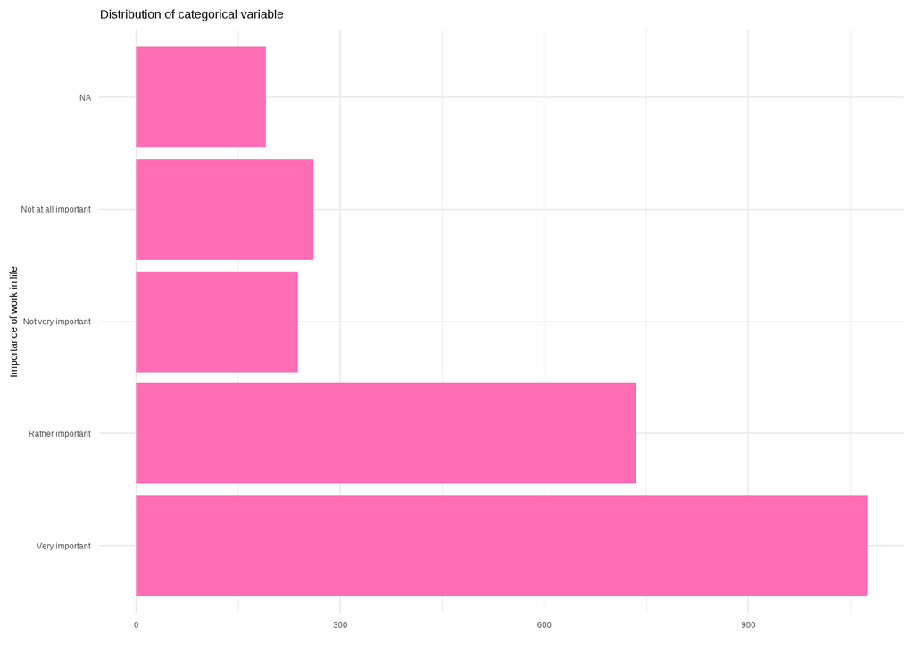

```r
p5 +labs(title = 'Distribution of categorical variable')
```

**Importance of work in life**: the majority of the respondents believe that work in life is very important (1075 people), 735 reported that work is rather important, 238 said that it is not very important and 261 people believe that work is not important at all. As wee see there is also some missing data.

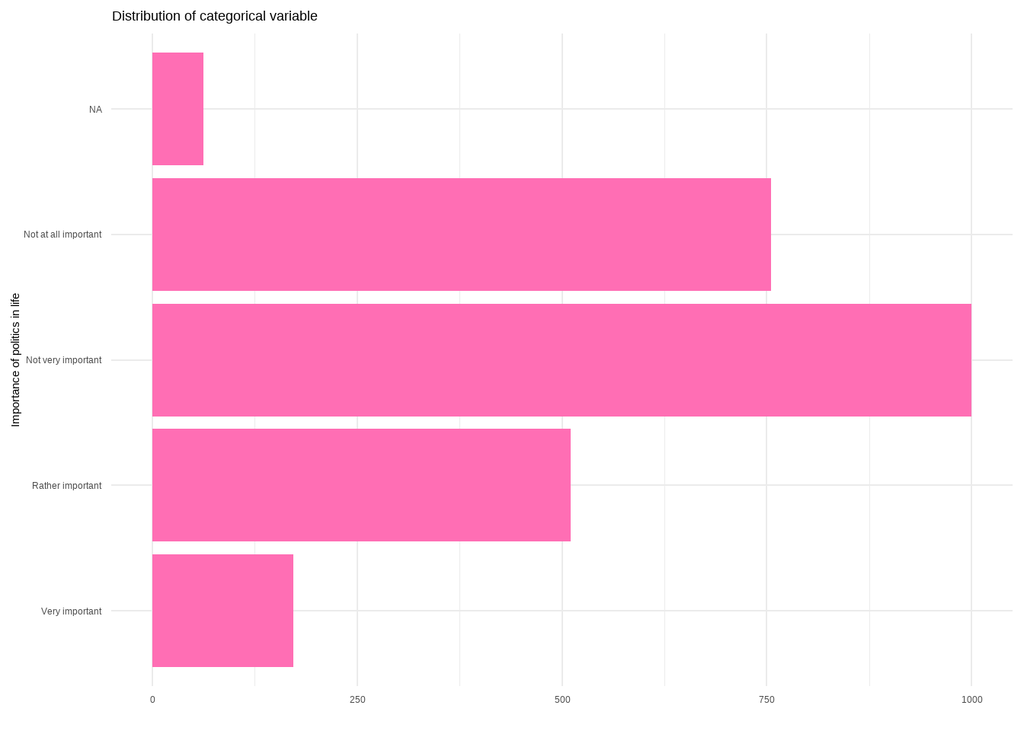

```r
p6 +labs( title = 'Distribution of categorical variable')
```

**Importance of politics in life**: the majority of the respondents believe that politics is not very important in life (1000 people), 755 reported that it is not important at all, 511 said that it is rather important and 172 people believe that politics is very important. For this variable there is also some missing data.

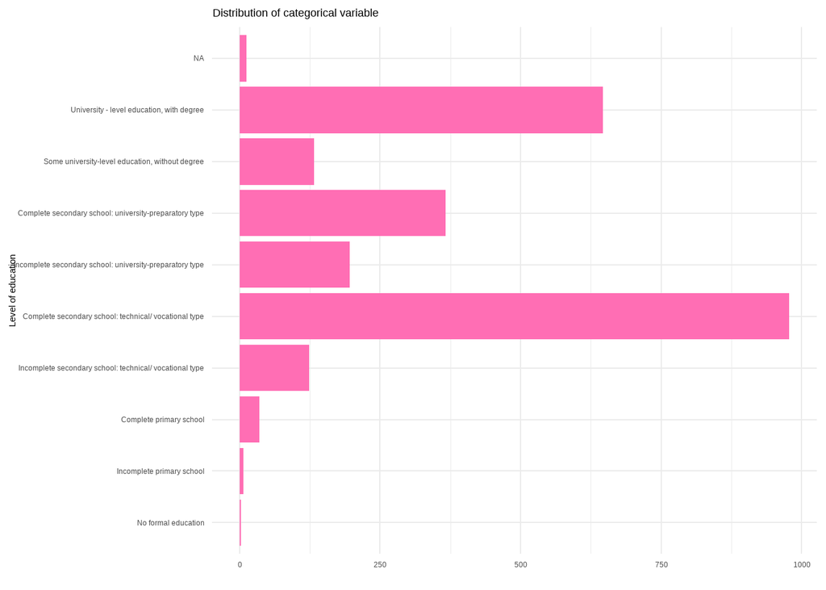

```r
p2 +labs( title = 'Distribution of categorical variable')
```

**Level of education**: distribution is not even, some categories are standing out too much (University and complete secondary school) education, and some almost completely missing (Incomplete and no formal education). Missing data is presented.

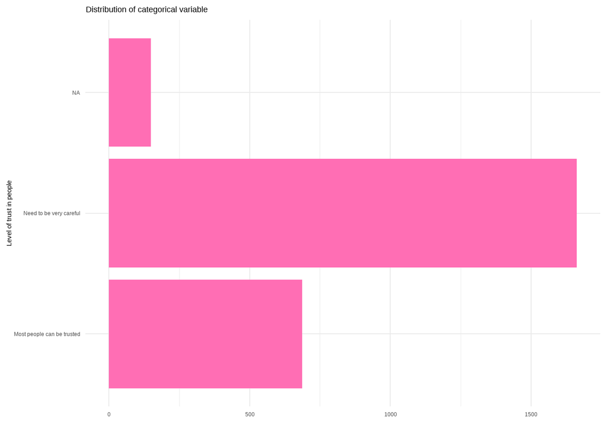

```r
p7 +labs( title = 'Distribution of categorical variable')
```

**Level of trust in people**: distribution is not even again, some people believe that one should be very careful with people, so their level of trust is rather low (1663 people) and 687 believe that most people can be trusted. Missing data is also presented.

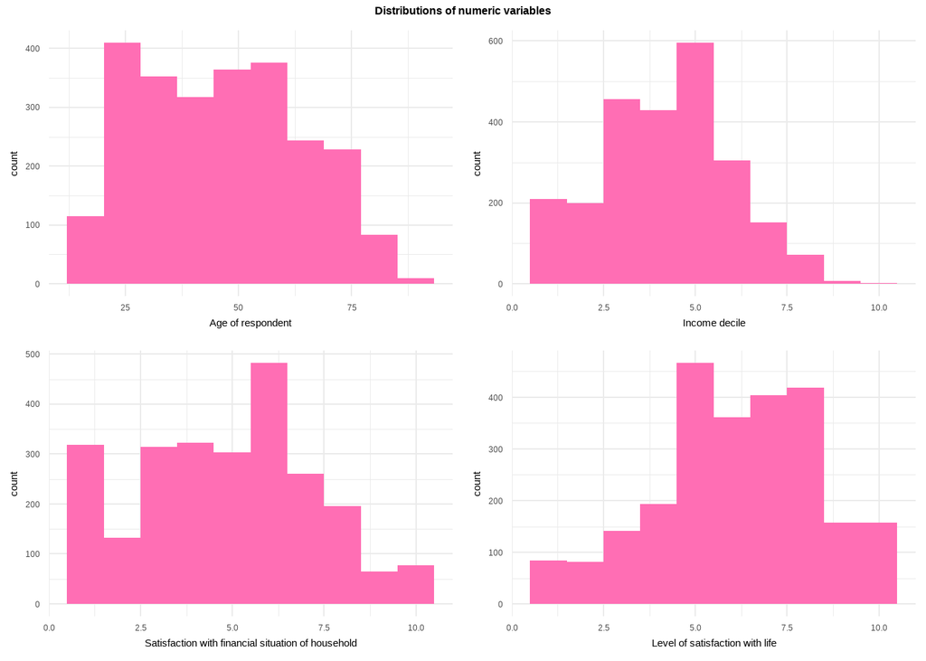

```r
pl1 <- ggplot(data1, aes(x = age)) +
  geom_histogram(fill = "#FF6EB4", bins=10)+
  labs(x="Age of respondent") +
  theme_minimal()
pl2 <- ggplot(data1, aes(x = income)) +
  geom_histogram(fill = "#FF6EB4", bins =10)+
  labs(x="Income decile")  +
  theme_minimal()
pl3 <- ggplot(data1, aes(x = satisf_fin)) +
  geom_histogram(fill = "#FF6EB4", bins =10)+
  labs(x="Satisfaction with financial situation of household")  +
  theme_minimal()

pl4 <- ggplot(data1, aes(x = satisf_life)) +
  geom_histogram(fill = "#FF6EB4", bins =10)+
  labs(x="Level of satisfaction with life")  +
  theme_minimal()

combined_plot <- ggarrange(pl1, pl2, pl3, pl4, nrow = 2, ncol = 2)
annotate_figure(combined_plot, top = text_grob("Distributions of numeric variables",face = "bold"))
```

```r
df2=data1

df2$`Age of respondent` = df2$age
df2$`Income decile` = df2$income
df2$`Satisfaction with financial situation of household` = df2$satisf_fin
df2$`Satisfaction with life` = df2$satisf_life

knitr::kable(describe(df2[c('Age of respondent', 'Income decile', 'Satisfaction with financial situation of household', 'Satisfaction with life')])) %>%
kable_styling(bootstrap_options = c("striped", "hover"))
```

|  | vars | n | mean | sd | median | trimmed | mad | min | max | range | skew | kurtosis | se |
| --- | --- | --- | --- | --- | --- | --- | --- | --- | --- | --- | --- | --- | --- |
| Age of respondent | 1 | 2500 | 46.056400 | 17.417973 | 46 | 45.415000 | 20.7564 | 18 | 91 | 73 | 0.2329557 | -0.9299343 | 0.3483595 |
| Income decile | 2 | 2425 | 4.207835 | 1.769662 | 4 | 4.201958 | 1.4826 | 1 | 10 | 9 | 0.0359422 | -0.4305374 | 0.0359364 |
| Satisfaction with financial situation of household | 3 | 2475 | 4.843636 | 2.384815 | 5 | 4.818778 | 2.9652 | 1 | 10 | 9 | 0.0427417 | -0.7284559 | 0.0479366 |
| Satisfaction with life | 4 | 2465 | 6.126978 | 2.196261 | 6 | 6.205778 | 2.9652 | 1 | 10 | 9 | -0.3090917 | -0.3595900 | 0.0442360 |

- Normal skew is up to +-0.5, normal kurtosis is within +-1 from zero. At this point we can conclude that all numeric variables are normally distributed as skew and kurtosis are within prescribed limits. However, from the graphs we see that variables are not really normally distributed, also kurtosis of age and satisfaction with financial situation of household is really closed to the limits. But still we will consider them as normally distributed variables.
- Age has a ‘normal’ distribution with M = 46.05, SD = 17.42;
- Income in decile has a normal distribution with M = 4.2, SD = 1.77;
- Satisfaction with financial situation of household is also ‘normally’ distributed, M = 4.84, SD = 2.38;
- Satisfaction with life has a normal distribution with M = 6.1, SD = 2.19.

## Exploring & plotting NA

```r
library(misty)
na.test(data1)
```

```
##  Little's MCAR Test
##
##      n nIncomp nPattern   chi2  df  pval
##   2500     550       44 565.78 329 0.000
```

Null hypothesis here: it is MCAR (Missings Completely At Random). We have p-value less than 0.05, so we reject null hypothesis, that means that it is not MCAR

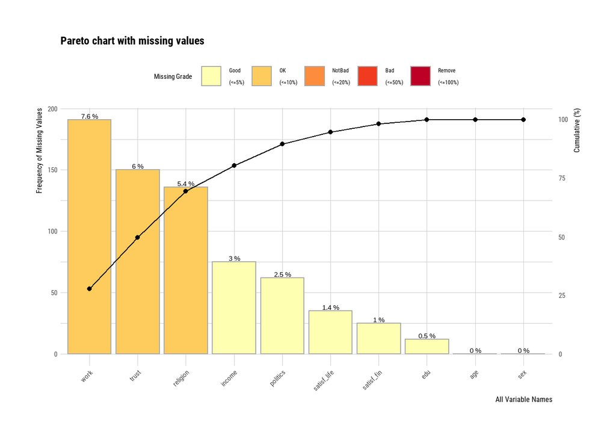

```r
plot_na_pareto(data1)
```

Out of 10 variables, we do have:

- 2 variables of age and sex with no missings. Though there is nothing to impute, these variables will help to impute NAs in other variables while modelling;
- 5 variables with a good proportion of NA’s from 0.5% to 3%. The closet to threshold of 5% amount of NA’s is being presented in the income variable;
- 3 variables of importance of religion and work, & trust in people possess an OK amount of NA’s from 5.4% to 7.6%. The importance of work in life do have the highest amount of NA’s among presented variables.

Satisfaction with life variable has only 1.4% of missings.

Next we would like to examine the interceptions between the variables NA’s presented in the data. The md patterns demonstrates how those NA’s intersect in a matrix, and the miss_upset plot shows those patterns in a visual representation (but only the top-5 vars by number of missings).

```r
mdpat <- md.pattern(data1, plot = FALSE, rotate.names = FALSE)
head(mdpat)
```

```
##      sex age edu satisf_fin satisf_life politics income religion trust work
## 1950   1   1   1          1           1        1      1        1     1    1 0
## 142    1   1   1          1           1        1      1        1     1    0 1
## 106    1   1   1          1           1        1      1        1     0    1 1
## 10     1   1   1          1           1        1      1        1     0    0 2
## 87     1   1   1          1           1        1      1        0     1    1 1
## 12     1   1   1          1           1        1      1        0     1    0 2
```

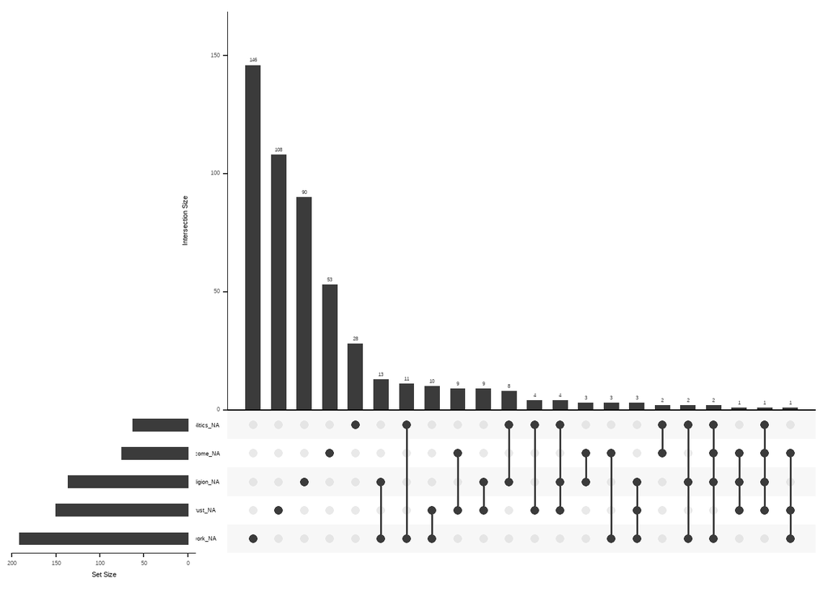

```r
gg_miss_upset(data1)
```

When considering the number of missing values for different combinations of the top five variables, we observe that the largest number of NA for the variables in our case are individual unique missing values - missing values without any intersections.

- work - 146 missing with no intersects;
- trust - 108 missing with no intersects;
- religion - 90 missing with no intersects;
- income - 53 missing with no intersects;
- politics - 28 missing with no intersects.

All the numbers of NA in the intersections of two or more variables do not exceed 13. The first highest number of NA-intersections is observed for the variables work and religion, the second for work and politics, the third for trust and work. Each of the top 5 variables has 8-10 intersections of NA with other variables.

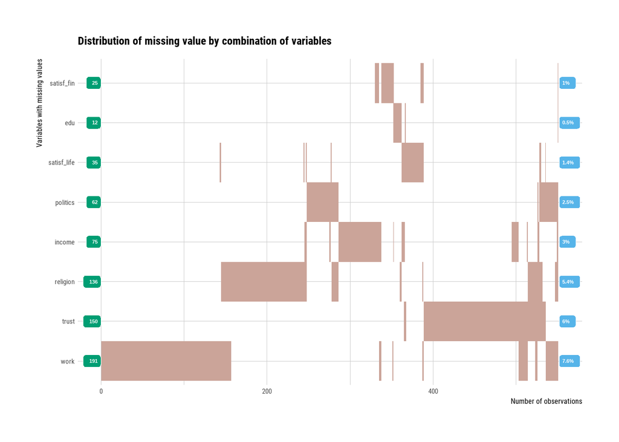

```r
plot_na_hclust(data1)
```

The distribution of missing value by combination of variables graph demonstrates as well that most of NA’s do exist in individual big chunks with no other observations.

Since the MCAR test has demonstrated that it is not the Missing completely at random type of missing, as well as it is difficult to detect any logical pattern in the missing intersection (most of NA’s are individual for each variable), we cannot make clear conclusions about whether we are dealing with MAR or MNAR. Yet, we make an assumption that with the absence or patterns of not answering from respondents side, the NA’s could have occurred more randomly - so we suggest it to be MAR.

## Imputation

### Amelia

Now we are going to perform the first method of imputation - Amelia.

We decided to perform 4 variances of imputation. All the variables that presented in the dataset are included in imputation model, having 4 ordinal and 6 nominal ones. We will take the first imputation with the highest chain length.

```r
set.seed(1055)
imputation <- amelia(data1, m = 4, noms = c('sex', 'edu','religion','work','politics', 'trust'),  ords = c("age", "satisf_fin", "income", "satisf_life"))
```

```
## -- Imputation 1 --
##
##   1  2  3  4  5  6  7  8  9
##
## -- Imputation 2 --
##
##   1  2  3  4  5  6  7  8
##
## -- Imputation 3 --
##
##   1  2  3  4  5  6  7
##
## -- Imputation 4 --
##
##   1  2  3  4  5  6
```

```r
imputation
```

```
##
## Amelia output with 4 imputed datasets.
## Return code:  1
## Message:  Normal EM convergence.
##
## Chain Lengths:
## --------------
## Imputation 1:  9
## Imputation 2:  8
## Imputation 3:  7
## Imputation 4:  6
```

```r
imp1 <- imputation$imputations$imp1
sum(is.na(imp1))
```

```
## [1] 0
```

Here we see that there are no missing values.

After the imputation we want to make diagnostics of it using summary and comparison of “before”*&* “after” distributions of variables.

Let’s have a look at the distribution of categorical variables and compare with original data:

(Red color - original data, purple color - overlay of original data and imputed data, blue color - imputed data)

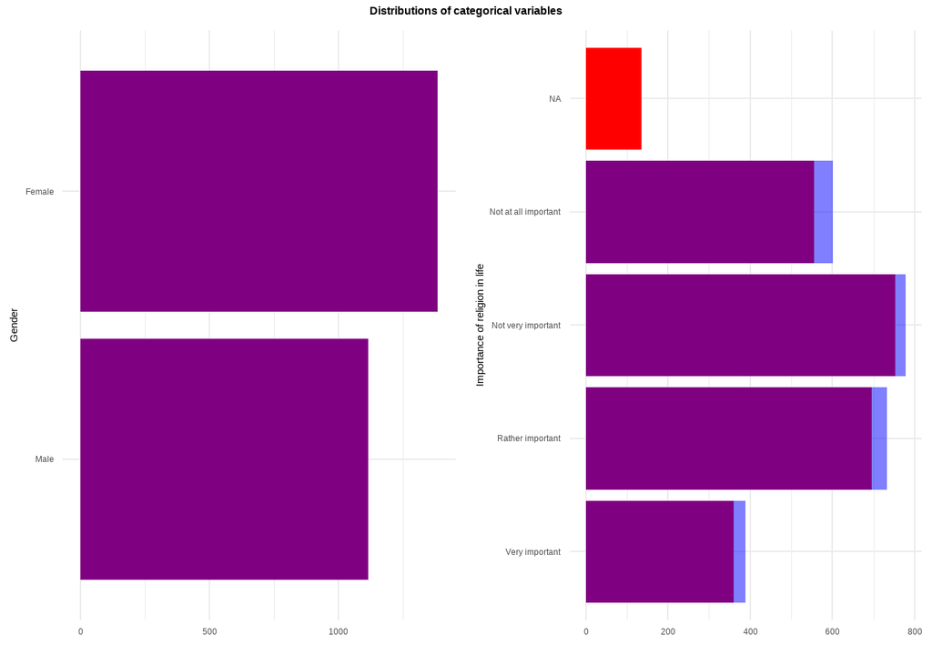

```r
p1 <- ggplot() +
  geom_bar(data = data1, aes(sex), fill = "red") +
  geom_bar(data = imp1, aes(sex), fill = "blue", alpha = 0.5) +
  labs(x="Gender",y="") +
  coord_flip() +
  theme_minimal()

p2 <- ggplot() +
  geom_bar(data = data1, aes(edu), fill = "red") +
  geom_bar(data = imp1, aes(edu), fill = "blue", alpha = 0.5) +
  labs(x="Level of education",y="") +
  coord_flip() +
  theme_minimal()

p4 <- ggplot() +
  geom_bar(data = data1, aes(religion), fill = "red") +
  geom_bar(data = imp1, aes(religion), fill = "blue", alpha = 0.5) +
  labs(x="Importance of religion in life",y="") +
  coord_flip() +
  theme_minimal()

p5 <- ggplot() +
  geom_bar(data = data1, aes(work), fill = "red") +
  geom_bar(data = imp1, aes(work), fill = "blue", alpha = 0.5) +
  labs(x="Importance of work in life",y="") +
  coord_flip() +
  theme_minimal()

p6 <- ggplot() +
  geom_bar(data = data1, aes(politics), fill = "red") +
  geom_bar(data = imp1, aes(politics), fill = "blue", alpha = 0.5) +
  labs(x="Importance of politics in life",y="") +
  coord_flip() +
  theme_minimal()

p7 <- ggplot() +
  geom_bar(data = data1, aes(trust), fill = "red") +
  geom_bar(data = imp1, aes(trust), fill = "blue", alpha = 0.5) +
  labs(x="Importance of trust in people",y="") +
  coord_flip() +
  theme_minimal()

combined_plot1 <- ggarrange(p1,p4, widths = c(2,2))
annotate_figure(combined_plot1, top = text_grob("Distributions of categorical variables", face = "bold"))
```

In case of gender, there was nothing to impute, so the distributions are the same. In case of importance of religion in life, we can see that NAs almost evenly moved to 4 other categories (though in the case of “not al all important” there are more imputed observations that in other levels).

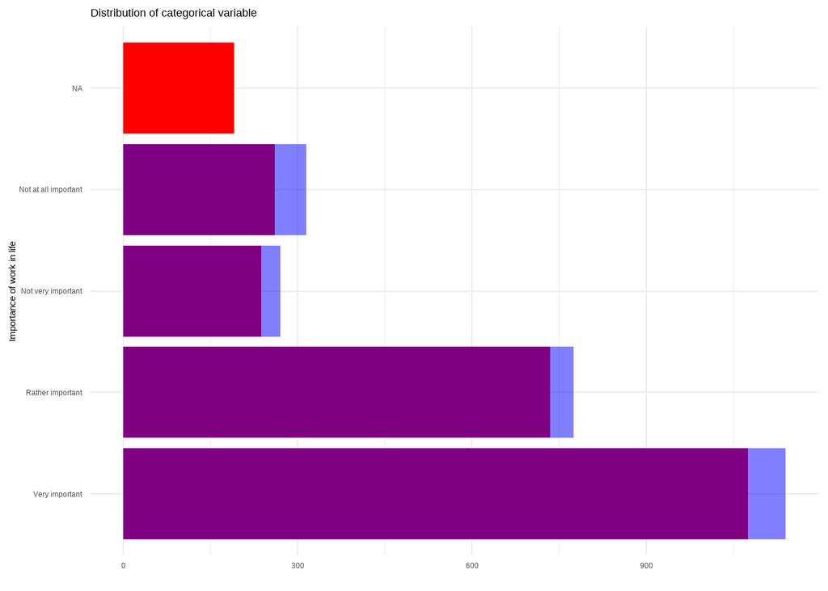

```r
p5 +labs(title = 'Distribution of categorical variable')
```

We can see that NAs almost evenly moved to 4 categories (though in the case of “very important” there are more imputed observations that in other levels).

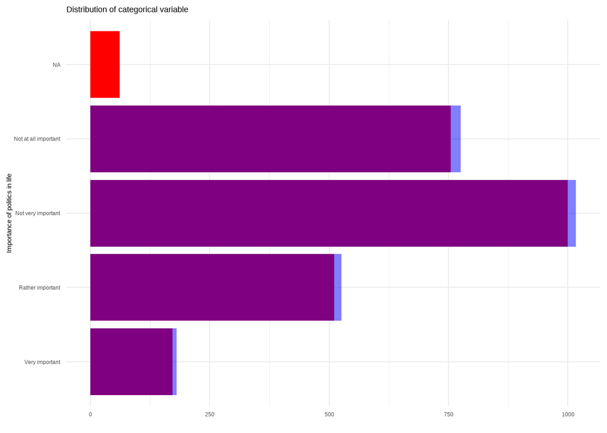

```r
p6 +labs( title = 'Distribution of categorical variable')
```

We can see that NAs almost evenly moved to 4 categories.

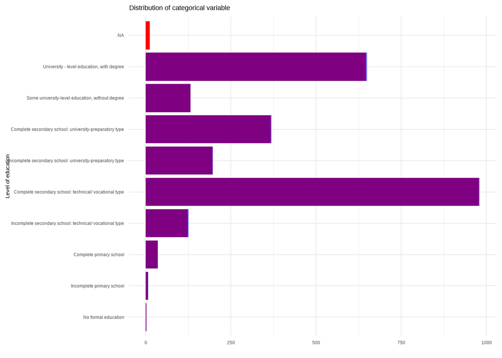

```r
p2 +labs( title = 'Distribution of categorical variable')
```

We can see that more NAs moved to “University” level than to others, that’s interesting.

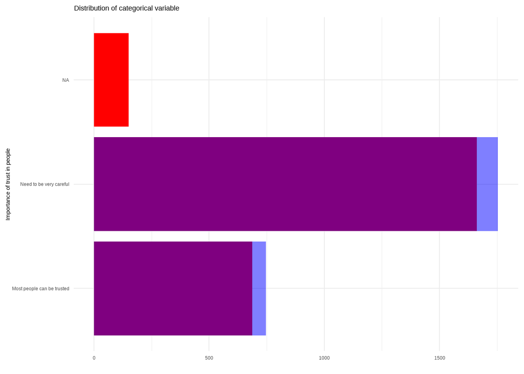

```r
p7 +labs( title = 'Distribution of categorical variable')
```

We can see that NAs almost evenly moved to both categories (in case of “Need to be very careful” there are a little more imputed data).

**And numeric data:**

(Red color - original data, purple color - overlay of original data and imputed data, blue color - imputed data)

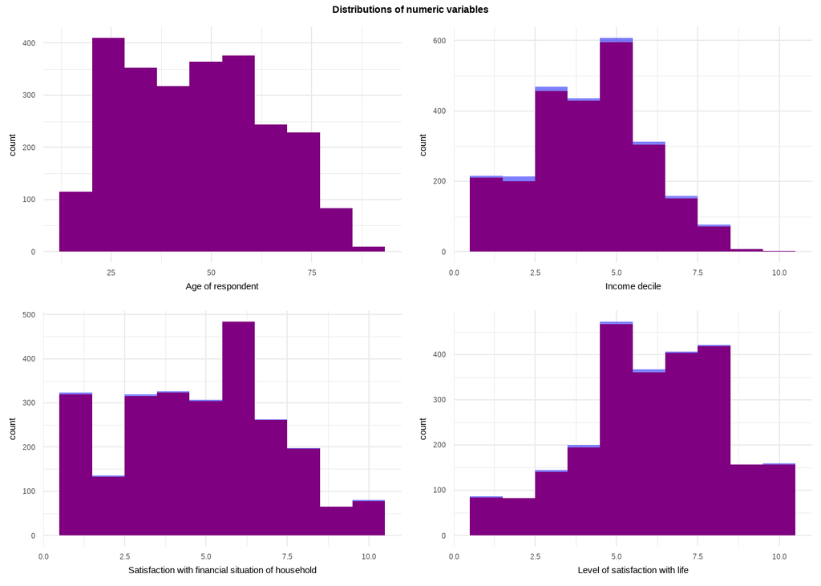

```r
pl1 <- ggplot() +
  geom_histogram(data = data1, aes(age), fill = "red", bins=10)+
  geom_histogram(data = imp1, aes(age), fill = "blue", alpha = 0.5, bins=10)+
  labs(x="Age of respondent")+
  theme_minimal()

pl2 <- ggplot() +
  geom_histogram(data = data1, aes(income), fill = "red", bins=10)+
  geom_histogram(data = imp1, aes(income), fill = "blue", alpha = 0.5, bins=10)+
  labs(x="Income decile")+
  theme_minimal()

pl3 <- ggplot() +
  geom_histogram(data = data1, aes(satisf_fin), fill = "red", bins=10)+
  geom_histogram(data = imp1, aes(satisf_fin), fill = "blue", alpha = 0.5, bins=10)+
  labs(x="Satisfaction with financial situation of household")+
  theme_minimal()

pl4 <- ggplot() +
  geom_histogram(data = data1, aes(satisf_life), fill = "red", bins=10)+
  geom_histogram(data = imp1, aes(satisf_life), fill = "blue", alpha = 0.5, bins=10)+
  labs(x="Level of satisfaction with life")+
  theme_minimal()

combined_plot <- ggarrange(pl1, pl2, pl3,pl4, nrow = 2, ncol = 2)
annotate_figure(combined_plot, top = text_grob("Distributions of numeric variables",face = "bold"))
```

We can see that distribution hasn’t changed significantly after imputation, that’s good!

### Mice method

Before performing the second method we need to separate our datatset into subsets of only categorical and only numeric variables, since different methods (polyreg and pmm) should be implemented for them.

```r
df_num = data1 %>% dplyr::select(age, income, satisf_fin, satisf_life)
df_cat = data1 %>% dplyr::select(sex, edu, religion, work, politics, trust)
```

We decided to perform 4 variances of imputation.

We should examine the convergence plot to ensure that the imputation process has stabilized across multiple iterations. A stable pattern indicates that the imputed values are not changing significantly with additional iterations.

```r
imputation_cat <- mice(df_cat, m = 4, method = "polyreg")
```

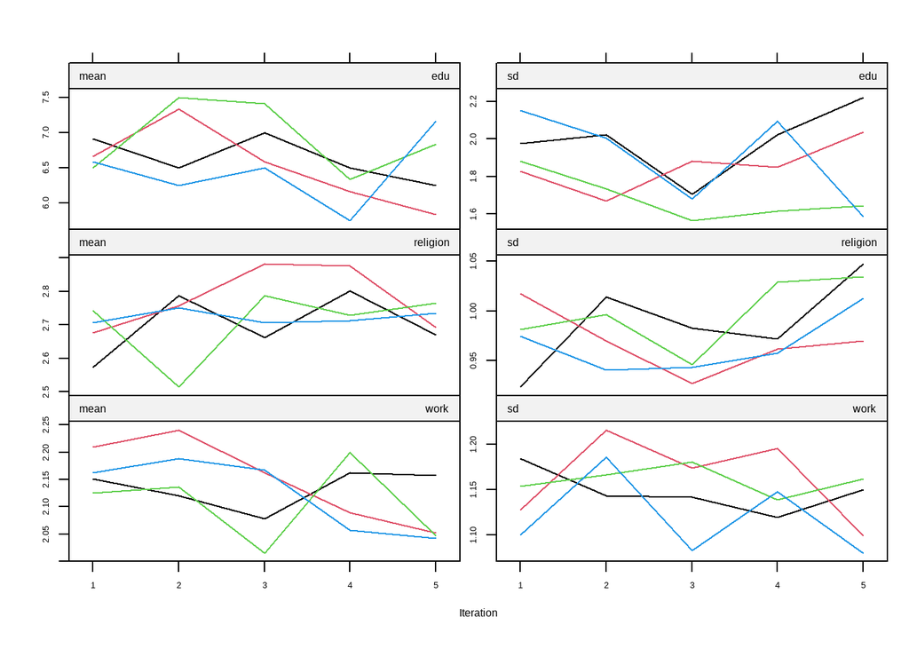

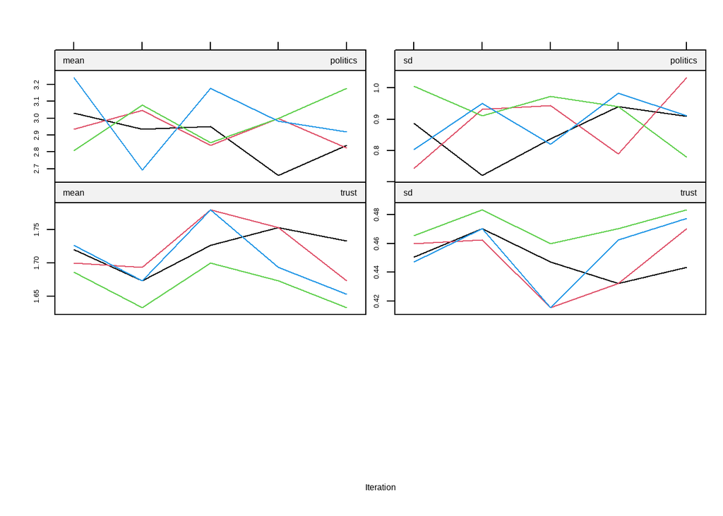

```r
plot(imputation_cat)
```

Unfortunately, we can not see some stable pattern here that tells us that imputation is not the best one.

Now let’s proceed to numeric variables.

```r
imputation_num <- mice(df_num, m = 4, method = "pmm")
```

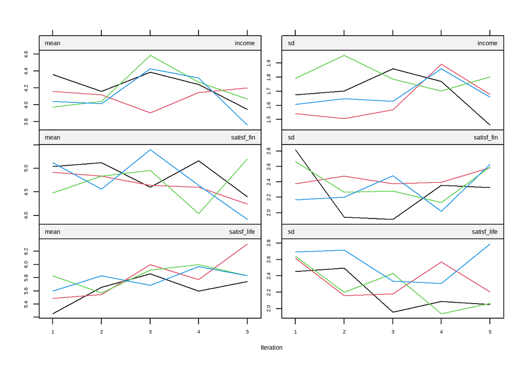

```r
plot(imputation_num)
```

Unfortunately, we also can not see stable pattern here as well as in the case of categorical variables, that tells us that Mice imputation method is not the best one for our case.

### Missranger method

Let’s make an imputation using Missranger method based on chained random forest, having number of trees set as 1000.

```r
mr_imputed <- missRanger(
  data1,
  formula = . ~ . ,
  num.trees = 1000,
  verbose = 2,
  seed = 111,
  returnOOB = T)
```

```
##
## Missing value imputation by random forests
##
##   Variables to impute:       edu, income, satisf_life, work, religion, politics, satisf_fin, trust
##   Variables used to impute:  sex, age, edu, income, satisf_life, work, religion, politics, satisf_fin, trust
##
##  edu stsf_f  stsf_l  poltcs  income  relign  trust   work
## iter 1:  0.5957  0.9962  0.9606  0.6091  0.7376  0.6197  0.3026  0.5292
## iter 2:  0.0060  0.0132  0.0156  0.0000  0.0176  0.0000  0.0000  0.0000
## iter 3:  0.0080  0.0133  0.0154  0.0000  0.0176  0.0000  0.0000  0.0000
```

Now let’s have a look at the distribution of categorical variables to compare them with original data:

(Red color - original data, purple color - overlay of original data and imputed data, blue color - imputed data)

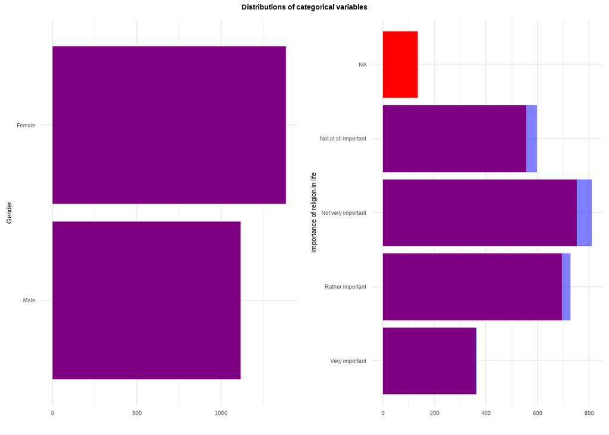

```r
pm1 <- ggplot() +
  geom_bar(data = data1, aes(sex), fill = "red") +
  geom_bar(data = mr_imputed, aes(sex), fill = "blue", alpha = 0.5) +
  labs(x="Gender",y="") +
  coord_flip() +
  theme_minimal()

pm2 <- ggplot() +
  geom_bar(data = data1, aes(edu), fill = "red") +
  geom_bar(data = mr_imputed, aes(edu), fill = "blue", alpha = 0.5) +
  labs(x="Level of education",y="") +
  coord_flip() +
  theme_minimal()

pm4 <- ggplot() +
  geom_bar(data = data1, aes(religion), fill = "red") +
  geom_bar(data = mr_imputed, aes(religion), fill = "blue", alpha = 0.5) +
  labs(x="Importance of religion in life",y="") +
  coord_flip() +
  theme_minimal()

pm5 <- ggplot() +
  geom_bar(data = data1, aes(work), fill = "red") +
  geom_bar(data = mr_imputed, aes(work), fill = "blue", alpha = 0.5) +
  labs(x="Importance of work in life",y="") +
  coord_flip() +
  theme_minimal()

pm6 <- ggplot() +
  geom_bar(data = data1, aes(politics), fill = "red") +
  geom_bar(data = mr_imputed, aes(politics), fill = "blue", alpha = 0.5) +
  labs(x="Importance of politics in life",y="") +
  coord_flip() +
  theme_minimal()

pm7 <- ggplot() +
  geom_bar(data = data1, aes(trust), fill = "red") +
  geom_bar(data = mr_imputed, aes(trust), fill = "blue", alpha = 0.5) +
  labs(x="Importance of trust in people",y="") +
  coord_flip() +
  theme_minimal()

combined_plotm1 <- ggarrange(pm1,pm4, widths = c(2,2))
annotate_figure(combined_plotm1, top = text_grob("Distributions of categorical variables", face = "bold"))
```

In case of gender, there was nothing to impute, so the distributions are the same. In case of importance of religion in life, we can see that most NAs moved to category “Not very important” and that’s logical as there are more observations with this level in the original dataset.

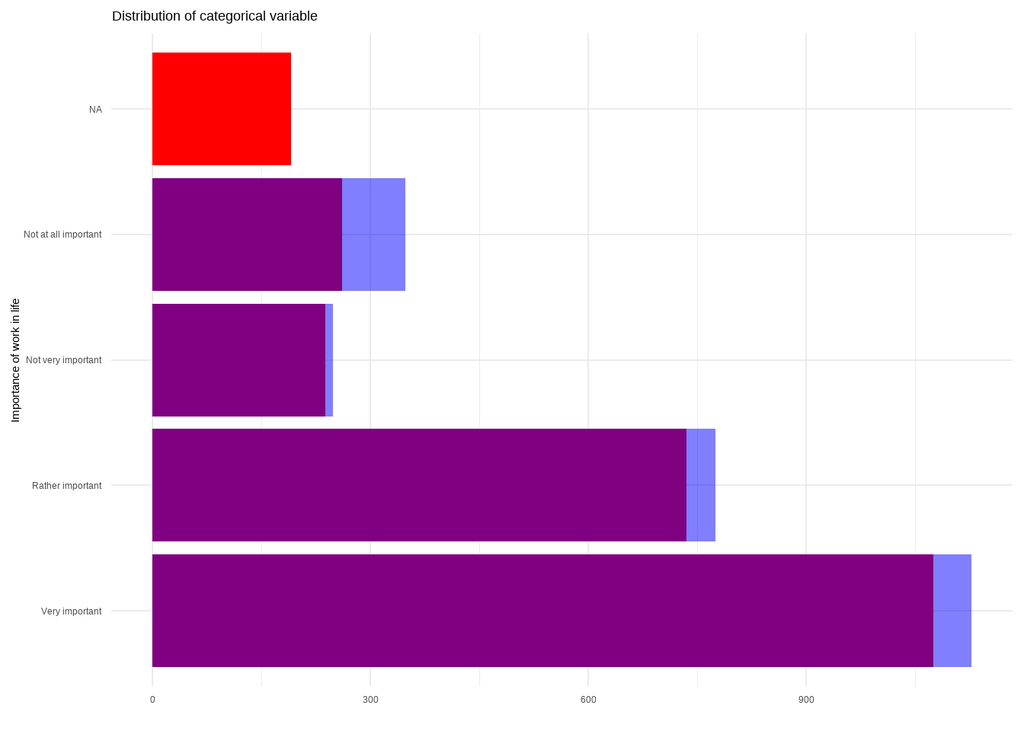

```r
pm5 +labs(title = 'Distribution of categorical variable')
```

We can see that most NAs moved to category “Not at all important” and that’s an interesting case as there are not so many observations in the original dataset of this level.

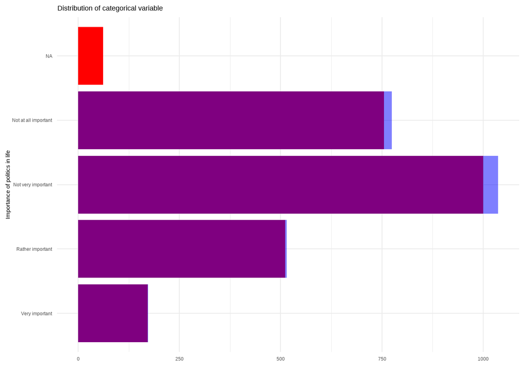

```r
pm6 +labs( title = 'Distribution of categorical variable')
```

We can see that most NAs moved to categories “Not very important” and “Not al all important” that’s logical as there are more observations with these levels in the original dataset.

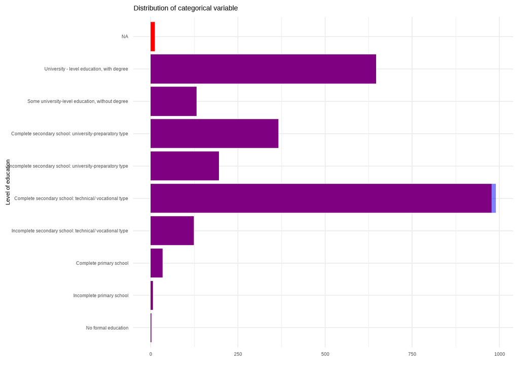

```r
pm2 +labs( title = 'Distribution of categorical variable')
```

We can see that most NAs moved to category “Complete secondary school: technical/vocational type” and that’s logical as there are more observations with this level in the original dataset.

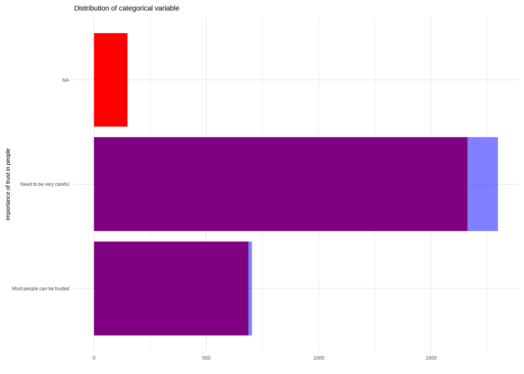

```r
pm7 +labs( title = 'Distribution of categorical variable')
```

We can see that most NAs moved to category “Need to be very careful” and that’s logical as there are more observations with this level in the original dataset.

**And numeric data:**

(Red color - original data, purple color - overlay of original data and imputed data, blue color - imputed data)

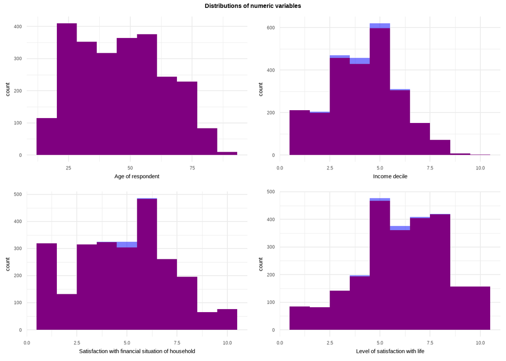

```r
plm1 <- ggplot() +
  geom_histogram(data = data1, aes(age), fill = "red", bins=10)+
  geom_histogram(data = mr_imputed, aes(age), fill = "blue", alpha = 0.5, bins=10)+
  labs(x="Age of respondent")+
  theme_minimal()

plm2 <- ggplot() +
  geom_histogram(data = data1, aes(income), fill = "red", bins=10)+
  geom_histogram(data = mr_imputed, aes(income), fill = "blue", alpha = 0.5, bins=10)+
  labs(x="Income decile")+
  theme_minimal()

plm3 <- ggplot() +
  geom_histogram(data = data1, aes(satisf_fin), fill = "red", bins=10)+
  geom_histogram(data = mr_imputed, aes(satisf_fin), fill = "blue", alpha = 0.5, bins=10)+
  labs(x="Satisfaction with financial situation of household")+
  theme_minimal()

plm4 <- ggplot() +
  geom_histogram(data = data1, aes(satisf_life), fill = "red", bins=10)+
  geom_histogram(data = mr_imputed, aes(satisf_life), fill = "blue", alpha = 0.5, bins=10)+
  labs(x="Level of satisfaction with life")+
  theme_minimal()

combined_plotmml <- ggarrange(plm1, plm2, plm3,plm4, nrow = 2, ncol = 2)
annotate_figure(combined_plotmml, top = text_grob("Distributions of numeric variables",face = "bold"))
```

We can see that distribution hasn’t changed significantly after imputation, that’s good!

### Choice of imputation method

If we had to choose which imputation should be used for some other modelling/work in general, we would have chosen the Amelia method and its first imputation out of series as it imputes NAs trying to save the initial distribution.

## Estimation of performed imputation

Here we will estimate our Amelia imputation with Zelig package. We can use the output object from the Amelia package directly in the data argument for Zelig:

```r
library(Zelig)
z.out <- zelig(satisf_life ~ sex + age + edu + income + work + religion + politics + satisf_fin + trust , model = "ls", data = imputation)
```

```
## How to cite this model in Zelig:
##   R Core Team. 2007.
##   ls: Least Squares Regression for Continuous Dependent Variables
##   in Christine Choirat, Christopher Gandrud, James Honaker, Kosuke Imai, Gary King, and Olivia Lau,
##   "Zelig: Everyone's Statistical Software," https://zeligproject.org/
```

```r
summary(z.out)
```

```
## Model: Combined Imputations
##
##                                                             Estimate Std.Error
## (Intercept)                                                  3.47494   1.47386
## sexFemale                                                    0.07255   0.08555
## age                                                         -0.01372   0.00285
## eduIncomplete primary school                                 1.29219   1.62802
## eduComplete primary school                                   1.82262   1.47331
## eduIncomplete secondary school: technical/ vocational type   1.46844   1.45094
## eduComplete secondary school: technical/ vocational type     1.42654   1.43758
## eduIncomplete secondary school: university-preparatory type  1.49478   1.44211
## eduComplete secondary school: university-preparatory type    1.51682   1.44163
## eduSome university-level education, without degree           1.22740   1.44883
## eduUniversity - level education, with degree                 1.43412   1.43777
## income                                                       0.30860   0.02688
## workRather important                                        -0.22306   0.09896
## workNot very important                                      -0.41525   0.17834
## workNot at all important                                    -0.27089   0.15538
## religionRather important                                    -0.02804   0.13501
## religionNot very important                                  -0.03825   0.13497
## religionNot at all important                                -0.22195   0.14361
## politicsRather important                                     0.09937   0.17825
## politicsNot very important                                   0.27488   0.16925
## politicsNot at all important                                 0.12064   0.17748
## satisf_fin                                                   0.15854   0.01823
## trustNeed to be very careful                                -0.31176   0.09840
##                                                             z value Pr(>|z|)
## (Intercept)                                                    2.36   0.0184
## sexFemale                                                      0.85   0.3964
## age                                                           -4.82  1.4e-06
## eduIncomplete primary school                                   0.79   0.4274
## eduComplete primary school                                     1.24   0.2161
## eduIncomplete secondary school: technical/ vocational type     1.01   0.3115
## eduComplete secondary school: technical/ vocational type       0.99   0.3210
## eduIncomplete secondary school: university-preparatory type    1.04   0.3000
## eduComplete secondary school: university-preparatory type      1.05   0.2927
## eduSome university-level education, without degree             0.85   0.3969
## eduUniversity - level education, with degree                   1.00   0.3185
## income                                                        11.48  < 2e-16
## workRather important                                          -2.25   0.0242
## workNot very important                                        -2.33   0.0199
## workNot at all important                                      -1.74   0.0813
## religionRather important                                      -0.21   0.8355
## religionNot very important                                    -0.28   0.7769
## religionNot at all important                                  -1.55   0.1222
## politicsRather important                                       0.56   0.5772
## politicsNot very important                                     1.62   0.1044
## politicsNot at all important                                   0.68   0.4967
## satisf_fin                                                     8.69  < 2e-16
## trustNeed to be very careful                                  -3.17   0.0015
##
## For results from individual imputed datasets, use summary(x, subset = i:j)
## Statistical Warning: The GIM test suggests this model is misspecified
##  (based on comparisons between classical and robust SE's; see http://j.mp/GIMtest).
##  We suggest you run diagnostics to ascertain the cause, respecify the model
##  and run it again.
##
## Next step: Use 'setx' method
```

We can also see the summary from imputed datasets *individually*.

```r
summary(z.out, subset = 1:4)
```

```
## Imputed Dataset 1
## Call:
## z5$zelig(formula = satisf_life ~ sex + age + edu + income + work +
##     religion + politics + satisf_fin + trust, data = imputation)
##
## Residuals:
##     Min      1Q  Median      3Q     Max
## -6.5174 -1.3603  0.0497  1.3315  6.2222
##
## Coefficients:
##                                                              Estimate
## (Intercept)                                                  3.418240
## sexFemale                                                    0.081699
## age                                                         -0.014133
## eduIncomplete primary school                                 1.566859
## eduComplete primary school                                   1.856185
## eduIncomplete secondary school: technical/ vocational type   1.483355
## eduComplete secondary school: technical/ vocational type     1.442414
## eduIncomplete secondary school: university-preparatory type  1.512663
## eduComplete secondary school: university-preparatory type    1.567304
## eduSome university-level education, without degree           1.262820
## eduUniversity - level education, with degree                 1.419890
## income                                                       0.318187
## workRather important                                        -0.211268
## workNot very important                                      -0.515732
## workNot at all important                                    -0.252946
## religionRather important                                     0.019742
## religionNot very important                                   0.007672
## religionNot at all important                                -0.176788
## politicsRather important                                     0.099187
## politicsNot very important                                   0.279916
## politicsNot at all important                                 0.086477
## satisf_fin                                                   0.155864
## trustNeed to be very careful                                -0.320184
##                                                             Std. Error t value
## (Intercept)                                                   1.468724   2.327
## sexFemale                                                     0.084790   0.964
## age                                                           0.002790  -5.066
## eduIncomplete primary school                                  1.594911   0.982
## eduComplete primary school                                    1.465648   1.266
```

[output cut: 299 more lines]

```
## politicsNot very important                                  0.086315
## politicsNot at all important                                0.437261
## satisf_fin                                                   < 2e-16
## trustNeed to be very careful                                0.002917
##
## Residual standard error: 2.015 on 2477 degrees of freedom
## Multiple R-squared:  0.1696, Adjusted R-squared:  0.1622
## F-statistic: 22.99 on 22 and 2477 DF,  p-value: < 2.2e-16
##
## Statistical Warning: The GIM test suggests this model is misspecified
##  (based on comparisons between classical and robust SE's; see http://j.mp/GIMtest).
##  We suggest you run diagnostics to ascertain the cause, respecify the model
##  and run it again.
##
## Next step: Use 'setx' method
```

Here we can see that based on Adjusted R-squared the best model is based on the 1st imputed dataset as it has the highest value (0.1671>0.1622>0.1598>0.1581)

When quantities of interest are plotted, such as expected and predicted values and first differenences, these are correctly pooled across those from each of the m imputed datasets

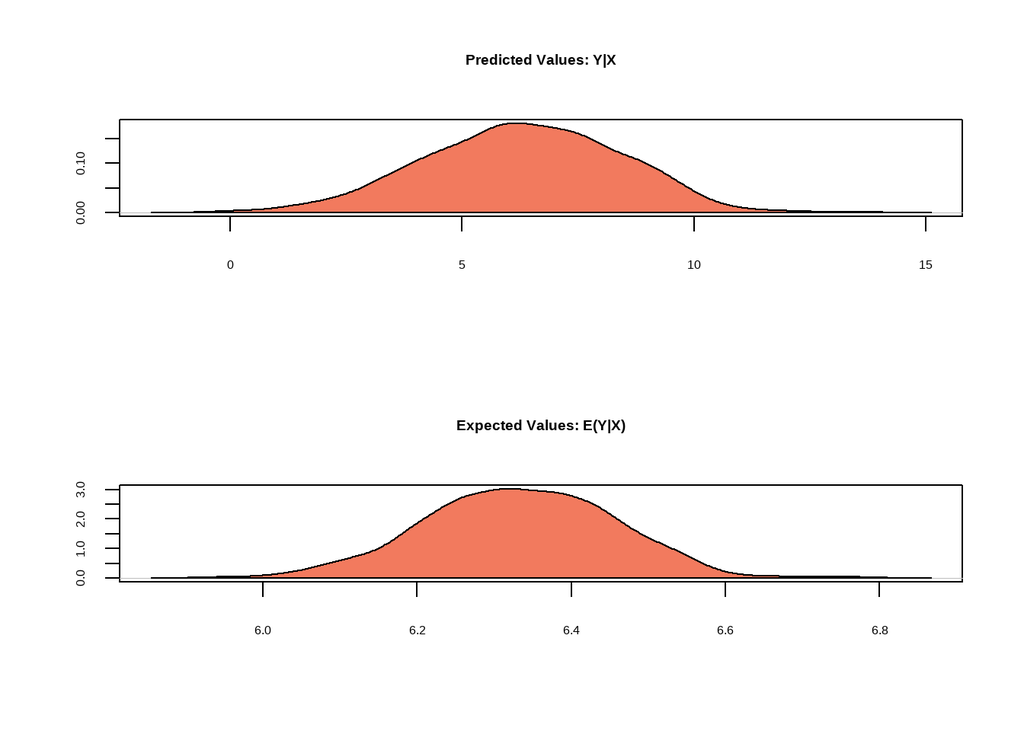

```r
z.out$setx()
z.out$sim()
plot(z.out)
```

All in all, we can see here normal distributions of both predicted and expected values that tells us that we have in general good imputations.